# R Workshop - Session 2

Naveen Venkataraman

April 18, 2015

# Overview of today’s session

1. Atomic Vectors
2. Matrices and Arrays

Next week:

3. Data frames
4. Factors
5. Lists

References for today’s session:

1. Advanced R by Hadley Wickham
2. The Art of R Programming by Norman Matloff

## Housekeeping Before We Begin

In R,

1. No static typing, means
   - No upfront variable type declarations necessary
   - Variable type can change without explicit recasting
2. Variable names can contain any combination of alphanumeric characters along with periods (.) and underscores (_). However, they cannot start with a number or an underscore
3. Index values start from 1 (starts from 0 in Java, C++ etc.) This means, there’s no 0-th element.

# Data Types in R

R’s data types can be organized based on:

1. Dimensionality
2. Homogenous (all contents are same)
3. Heterogenous (contents can be different)

| Dimension | Homogenous | Heterogenous |
| --- | --- | --- |
| 1d | Atomic Vector | List |
| 2d | Matrix | Data Frame |
| nd | Array |  |

## Vectors

Simplest data type in R. Variable types are called `modes`.

Note: R does not have a `scalar` data type. Scalars in R are vectors of length = 1.

Modes include:

1. numeric
   - integer (whole numbers, no decimals)
   - double (floating-point)
2. character (string)
3. logical
4. complex
5. raw

We will only talk about numeric, character and logical modes today.

### Numeric: double

```r
num_vec <- c(1,3,5)
num_vec
```

```
## [1] 1 3 5
```

```r
typeof(num_vec)
```

```
## [1] "double"
```

```r
is.numeric(num_vec)
```

```
## [1] TRUE
```

```r
is.double(num_vec)
```

```
## [1] TRUE
```

```r
(mode(num_vec) == "numeric")
```

```
## [1] TRUE
```

### Numeric: integer

```r
int_vec <- c(5L)

typeof(int_vec)
```

```
## [1] "integer"
```

```r
is.numeric(int_vec)
```

```
## [1] TRUE
```

```r
is.integer(int_vec)
```

```
## [1] TRUE
```

```r
is.double(int_vec)
```

```
## [1] FALSE
```

### Character vectors

```r
char_vec <- c("Hello", "World")

char_vec
```

```
## [1] "Hello" "World"
```

```r
typeof(char_vec)
```

```
## [1] "character"
```

```r
is.character(char_vec)
```

```
## [1] TRUE
```

```r
length(char_vec)
```

```
## [1] 2
```

### Logical vectors

```r
log_vec <- rep(c(TRUE, FALSE), each=20)
log_vec
```

```
##  [1]  TRUE  TRUE  TRUE  TRUE  TRUE  TRUE  TRUE  TRUE  TRUE  TRUE  TRUE
## [12]  TRUE  TRUE  TRUE  TRUE  TRUE  TRUE  TRUE  TRUE  TRUE FALSE FALSE
## [23] FALSE FALSE FALSE FALSE FALSE FALSE FALSE FALSE FALSE FALSE FALSE
## [34] FALSE FALSE FALSE FALSE FALSE FALSE FALSE
```

```r
is.logical(log_vec)
```

```
## [1] TRUE
```

```r
is.numeric(log_vec)
```

```
## [1] FALSE
```

```r
is.character(log_vec)
```

```
## [1] FALSE
```

#### Illustrating Usage of Logical Vector return values

```r
num <- c(1:50)

num %% 2 == 0
```

```
##  [1] FALSE  TRUE FALSE  TRUE FALSE  TRUE FALSE  TRUE FALSE  TRUE FALSE
## [12]  TRUE FALSE  TRUE FALSE  TRUE FALSE  TRUE FALSE  TRUE FALSE  TRUE
## [23] FALSE  TRUE FALSE  TRUE FALSE  TRUE FALSE  TRUE FALSE  TRUE FALSE
## [34]  TRUE FALSE  TRUE FALSE  TRUE FALSE  TRUE FALSE  TRUE FALSE  TRUE
## [45] FALSE  TRUE FALSE  TRUE FALSE  TRUE
```

```r
table(num %% 2 == 0)
```

```
##
## FALSE  TRUE
##    25    25
```

```r
which(num %% 2 == 0)
```

```
##  [1]  2  4  6  8 10 12 14 16 18 20 22 24 26 28 30 32 34 36 38 40 42 44 46
## [24] 48 50
```

```r
typeof(num %% 2 == 0)
```

```
## [1] "logical"
```

```r
## Complete.cases and is.na()
sample <- cbind(col1=rep(c(1,NA,3)),col2=rep(c(NA,4,6)))

typeof(sample)
```

```
## [1] "double"
```

```r
is.na(sample)
```

```
##       col1  col2
## [1,] FALSE  TRUE
## [2,]  TRUE FALSE
## [3,] FALSE FALSE
```

```r
complete.cases(sample)
```

```
## [1] FALSE FALSE  TRUE
```

### Type coercion

```r
int_vec <- c(int_vec, 6)

is.numeric(int_vec)
```

```
## [1] TRUE
```

```r
is.integer(int_vec)
```

```
## [1] FALSE
```

```r
is.double(int_vec)
```

```
## [1] TRUE
```

### Typecasting

```r
another_int_vec <- as.integer(3,19)

is.numeric(another_int_vec)
```

```
## [1] TRUE
```

```r
is.integer(another_int_vec)
```

```
## [1] TRUE
```

```r
is.double(another_int_vec)
```

```
## [1] FALSE
```

### Indexing

Individual elements are accessed via **`[ ]`** by using an **`index`** or **`subscript`**

```r
num_vec[1]
```

```
## [1] 1
```

```r
num_vec[2]
```

```
## [1] 3
```

```r
num_vec[4]
```

```
## [1] NA
```

```r
num_vec[0]
```

```
## numeric(0)
```

### Common Vector Operations

#### Adding and Removing elements

```r
num_vec[4] <- 7 ## You can only do this if you know the dimensions and if you know the last used index
num_vec
```

```
## [1] 1 3 5 7
```

```r
num_vec <- c(num_vec,9)
num_vec
```

```
## [1] 1 3 5 7 9
```

```r
num_vec <- num_vec[-1]
num_vec
```

```
## [1] 3 5 7 9
```

#### Math operations on vectors

Includes:

- addition: +
- subtraction: -
- multiplication: *
- division: /
- modulo: %%

```r
vec_1 <- seq(1:3)

length(vec_1)
```

```
## [1] 3
```

```r
#vec_2 <- seq(1:20, by=2)

vec_2 <- seq(1, 20, by=2)

length(vec_2)
```

```
## [1] 10
```

```r
## Recycling of smaller vectors when operating with larger vectors

vec_2
```

```
##  [1]  1  3  5  7  9 11 13 15 17 19
```

```r
vec_1
```

```
## [1] 1 2 3
```

```r
vec_2 + vec_1
```

```
##  [1]  2  5  8  8 11 14 14 17 20 20
```

```r
vec_3 <- seq(1, 20, by=3)

vec_3 + vec_1
```

```
## [1]  2  6 10 11 15 19 20
```

```r
1:10 %% 2
```

```
##  [1] 1 0 1 0 1 0 1 0 1 0
```

```r
## Seq in loop operations

x <- rnorm(5)

for(i in seq_along(x)) {
    print(x[i])
}
```

```
## [1] -1.260046
## [1] 0.4284301
## [1] 1.301398
## [1] -0.2017268
## [1] -0.5245303
```

#### Using rep()

```r
vec <- rep(1, 5)
vec
```

```
## [1] 1 1 1 1 1
```

```r
rep(c(5,12,13),3)
```

```
## [1]  5 12 13  5 12 13  5 12 13
```

```r
rep(c(5,12,13),each=2)
```

```
## [1]  5  5 12 12 13 13
```

#### Filtering: Conditional

```r
## Single condition

num_vec <- runif(5000, min=1, max=5000)

range(num_vec)
```

```
## [1]    1.122851 4999.927369
```

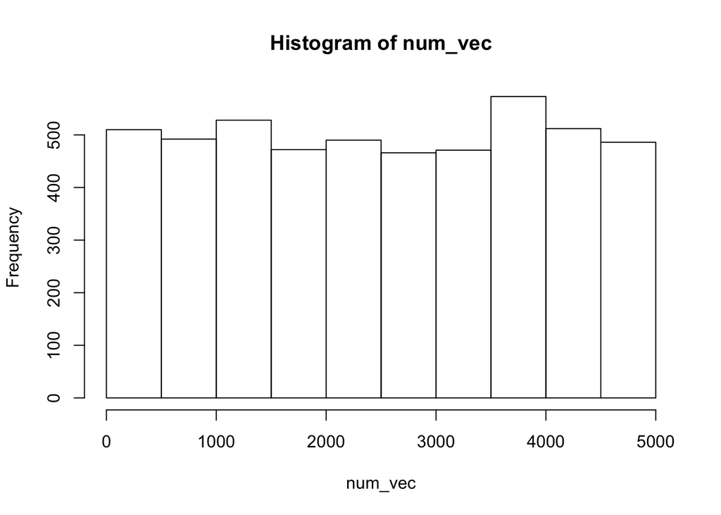

```r
hist(num_vec)
```

```r
#num_vec[num_vec >= 2500]

length(num_vec[num_vec >= 2500])
```

```
## [1] 2508
```

```r
## Compound conditions

comp_vec <- seq(1000)

range(comp_vec)
```

```
## [1]    1 1000
```

```r
length(comp_vec[(comp_vec >= 250 & comp_vec < 500)])
```

```
## [1] 250
```

#### Filtering: Using `subset`

```r
x <- c(6,1:3,NA,12)

x
```

```
## [1]  6  1  2  3 NA 12
```

```r
x[x > 5]
```

```
## [1]  6 NA 12
```

```r
subset(x, x > 5)
```

```
## [1]  6 12
```

#### Naming vector positions

```r
x <- 1:3
x
```

```
## [1] 1 2 3
```

```r
names(x) <- c("one", "two", "three")

x
```

```
##   one   two three
##     1     2     3
```

```r
x["one"]
```

```
## one
##   1
```

```r
x["two"]
```

```
## two
##   2
```

```r
x["three"]
```

```
## three
##     3
```

## Matrices and Arrays

1. A **Matrix** is a special type of array which has 2 dimensions.
2. A matrix is also a vector with two additional attributes:
   - the **number of rows**
   - the **number of columns**
3. Matrices and arrays are created with **matrix()** and **array()**,
4. You can check the dimensions using `dim()`

### Creating a matrix

```r
mat1 <- matrix(1:12)
mat1
```

```
##       [,1]
##  [1,]    1
##  [2,]    2
##  [3,]    3
##  [4,]    4
##  [5,]    5
##  [6,]    6
##  [7,]    7
##  [8,]    8
##  [9,]    9
## [10,]   10
## [11,]   11
## [12,]   12
```

```r
mat1 <- matrix(1:12, nrow=3)
mat1
```

```
##      [,1] [,2] [,3] [,4]
## [1,]    1    4    7   10
## [2,]    2    5    8   11
## [3,]    3    6    9   12
```

```r
mat1 <- matrix(1:12, ncol=3)
mat1
```

```
##      [,1] [,2] [,3]
## [1,]    1    5    9
## [2,]    2    6   10
## [3,]    3    7   11
## [4,]    4    8   12
```

```r
mat1 <- matrix(1:12, ncol=3, byrow=TRUE)
mat1
```

```
##      [,1] [,2] [,3]
## [1,]    1    2    3
## [2,]    4    5    6
## [3,]    7    8    9
## [4,]   10   11   12
```

### General Matrix Operations

#### Linear Algebra Operations Using Matrices

```r
mat1 <- matrix(1:4,nrow=2)
mat1
```

```
##      [,1] [,2]
## [1,]    1    3
## [2,]    2    4
```

```r
mat2 <- matrix(5:8,nrow=2)
mat2
```

```
##      [,1] [,2]
## [1,]    5    7
## [2,]    6    8
```

```r
## Matrix Addition

mat1 + mat2
```

```
##      [,1] [,2]
## [1,]    6   10
## [2,]    8   12
```

```r
mat3 <- matrix(1:9, nrow=3)
mat3
```

```
##      [,1] [,2] [,3]
## [1,]    1    4    7
## [2,]    2    5    8
## [3,]    3    6    9
```

```r
## Illustration of length difference
#mat1 + mat3

## Matrix Multiplication

mat1 %*% mat2 ## Note the %*% operator
```

```
##      [,1] [,2]
## [1,]   23   31
## [2,]   34   46
```

```r
## Regular element by element multiplication

mat1
```

```
##      [,1] [,2]
## [1,]    1    3
## [2,]    2    4
```

```r
mat2
```

```
##      [,1] [,2]
## [1,]    5    7
## [2,]    6    8
```

```r
mat1 * mat2
```

```
##      [,1] [,2]
## [1,]    5   21
## [2,]   12   32
```

```r
## Illustration of dimension difference

## mat1 %*% mat3

dim(mat1)
```

```
## [1] 2 2
```

```r
dim(mat3)
```

```
## [1] 3 3
```

```r
## Matrix element naming
mat1
```

```
##      [,1] [,2]
## [1,]    1    3
## [2,]    2    4
```

```r
names(mat1)
```

```r
names(mat1) <- c("a","b")

names(mat1)
```

```
## [1] "a" "b" NA  NA
```

```r
mat1
```

```
##      [,1] [,2]
## [1,]    1    3
## [2,]    2    4
## attr(,"names")
## [1] "a" "b" NA  NA
```

```r
mat1["a"]
```

```
## a
## 1
```

#### Matrix Indexing

Matrix indexing takes the form:

mat_variable[row, column]

```r
mat1 <- matrix(1:4,nrow=2)
mat1
```

```
##      [,1] [,2]
## [1,]    1    3
## [2,]    2    4
```

```r
mat1[1,] ## row
```

```
## [1] 1 3
```

```r
mat1[,1] ## column
```

```
## [1] 1 2
```

```r
mat1[1,2] ## unique element
```

```
## [1] 3
```

```r
mat1[-1,] ## excluding row
```

```
## [1] 2 4
```

```r
mat1[,-2] ## excluding column
```

```
## [1] 1 2
```

```r
## Changing specific rows

mat3 <- matrix(1:9, ncol=3)
mat3
```

```
##      [,1] [,2] [,3]
## [1,]    1    4    7
## [2,]    2    5    8
## [3,]    3    6    9
```

```r
mat3[c(1,3),] <- matrix(1:6, nrow=2, byrow=TRUE)
mat3
```

```
##      [,1] [,2] [,3]
## [1,]    1    2    3
## [2,]    2    5    8
## [3,]    4    5    6
```

```r
mat4 <- matrix(1:9, ncol=3)
mat4
```

```
##      [,1] [,2] [,3]
## [1,]    1    4    7
## [2,]    2    5    8
## [3,]    3    6    9
```

```r
mat4[,c(1,3)] <- matrix(10:15, nrow=2)
mat4
```

```
##      [,1] [,2] [,3]
## [1,]   10    4   13
## [2,]   11    5   14
## [3,]   12    6   15
```

#### Filtering Matrices

```r
mat5 <- matrix(c(1:6,rep(NA, 3),10:12), nrow=6)
mat5
```

```
##      [,1] [,2]
## [1,]    1   NA
## [2,]    2   NA
## [3,]    3   NA
## [4,]    4   10
## [5,]    5   11
## [6,]    6   12
```

```r
complete.cases(mat5)
```

```
## [1] FALSE FALSE FALSE  TRUE  TRUE  TRUE
```

```r
mat5[complete.cases(mat5),]
```

```
##      [,1] [,2]
## [1,]    4   10
## [2,]    5   11
## [3,]    6   12
```

```r
mat6 <- matrix(1:9, nrow=3, byrow=TRUE)
mat6
```

```
##      [,1] [,2] [,3]
## [1,]    1    2    3
## [2,]    4    5    6
## [3,]    7    8    9
```

```r
mat6[mat6[,2] > 4,]
```

```
##      [,1] [,2] [,3]
## [1,]    4    5    6
## [2,]    7    8    9
```

```r
## Be Cognizant of return types

mat7 <- matrix(seq(4),nrow=2)
mat7
```

```
##      [,1] [,2]
## [1,]    1    3
## [2,]    2    4
```

```r
attributes(mat7)
```

```
## $dim
## [1] 2 2
```

```r
mat8 <- mat7[,2]
mat8
```

```
## [1] 3 4
```

```r
attributes(mat8)
```

```r
## Using drop

mat9 <- mat7[,2,drop=FALSE]
mat9
```

```
##      [,1]
## [1,]    3
## [2,]    4
```

```r
attributes(mat9)
```

```
## $dim
## [1] 2 1
```

```r
## Using as.matrix

mat10 <- matrix(seq(25), nrow=5)
mat10
```

```
##      [,1] [,2] [,3] [,4] [,5]
## [1,]    1    6   11   16   21
## [2,]    2    7   12   17   22
## [3,]    3    8   13   18   23
## [4,]    4    9   14   19   24
## [5,]    5   10   15   20   25
```

```r
dim(mat10)
```

```
## [1] 5 5
```

```r
mat11 <- mat10[,c(2)]
mat11
```

```
## [1]  6  7  8  9 10
```

```r
dim(mat11)
```

```r
mat11 <- as.matrix(mat10[,c(2)])
mat11
```

```
##      [,1]
## [1,]    6
## [2,]    7
## [3,]    8
## [4,]    9
## [5,]   10
```

```r
dim(mat11)
```

```
## [1] 5 1
```

### Adding / Removing Matrix Rows and Columns

Technically, matrices are of fixed length and dimensions, so we cannot add or delete rows or columns. However, matrices can be reassigned, and thus we can achieve the same effect as if we had directly done additions or deletions.

This is done using `rbind()` (to append rows) and `cbind()` to append columns.

```r
mat1 <- matrix(1:20, nrow=5)
mat1
```

```
##      [,1] [,2] [,3] [,4]
## [1,]    1    6   11   16
## [2,]    2    7   12   17
## [3,]    3    8   13   18
## [4,]    4    9   14   19
## [5,]    5   10   15   20
```

```r
rbind(mat1, c(40:43))
```

```
##      [,1] [,2] [,3] [,4]
## [1,]    1    6   11   16
## [2,]    2    7   12   17
## [3,]    3    8   13   18
## [4,]    4    9   14   19
## [5,]    5   10   15   20
## [6,]   40   41   42   43
```

```r
mat1 <- rbind(mat1, c(40:43))
mat1
```

```
##      [,1] [,2] [,3] [,4]
## [1,]    1    6   11   16
## [2,]    2    7   12   17
## [3,]    3    8   13   18
## [4,]    4    9   14   19
## [5,]    5   10   15   20
## [6,]   40   41   42   43
```

```r
mat2 <- matrix(1:9, nrow=3, byrow = TRUE)
mat2
```

```
##      [,1] [,2] [,3]
## [1,]    1    2    3
## [2,]    4    5    6
## [3,]    7    8    9
```

```r
cbind(mat2, matrix(100:102, ncol=1))
```

```
##      [,1] [,2] [,3] [,4]
## [1,]    1    2    3  100
## [2,]    4    5    6  101
## [3,]    7    8    9  102
```

```r
mat2 <- cbind(mat2, matrix(100:102, ncol=1))
mat2
```

```
##      [,1] [,2] [,3] [,4]
## [1,]    1    2    3  100
## [2,]    4    5    6  101
## [3,]    7    8    9  102
```

## Arrays

### Creating an Array

```r
first <- matrix(seq(700,1500, by=100), nrow=3)
first
```

```
##      [,1] [,2] [,3]
## [1,]  700 1000 1300
## [2,]  800 1100 1400
## [3,]  900 1200 1500
```

```r
second <- matrix(seq(250,650, by=50), nrow=3)
second
```

```
##      [,1] [,2] [,3]
## [1,]  250  400  550
## [2,]  300  450  600
## [3,]  350  500  650
```

```r
third <- matrix(seq(2000,2800, by=100), nrow=3)
third
```

```
##      [,1] [,2] [,3]
## [1,] 2000 2300 2600
## [2,] 2100 2400 2700
## [3,] 2200 2500 2800
```

```r
a1 <- array(data=c(first, second, third), dim=c(3,3,3))
a1
```

```
## , , 1
##
##      [,1] [,2] [,3]
## [1,]  700 1000 1300
## [2,]  800 1100 1400
## [3,]  900 1200 1500
##
## , , 2
##
##      [,1] [,2] [,3]
## [1,]  250  400  550
## [2,]  300  450  600
## [3,]  350  500  650
##
## , , 3
##
##      [,1] [,2] [,3]
## [1,] 2000 2300 2600
## [2,] 2100 2400 2700
## [3,] 2200 2500 2800
```

```r
dim(a1)
```

```
## [1] 3 3 3
```